# There is no drivers!

Ardian

2023-08-13

#### **Import library** yang digunakan

```r
library(dplyr)
library(lubridate)
library(padr)
library(e1071)
library(caret)
library(partykit)
library(randomForest)
library(reshape2)
library(tidyverse)
library(tidymodels)
library(lime)
library(rmarkdown)
```

#### **Baca data** train

```r
train <- read.csv("data_input/data-train.csv")

train %>% head()
```

```
##                         id                  trip_id                driver_id
## 1 59d005e1ffcfa261708ce9cd 59d005e9cb564761a8fe5d3e 59a892c5568be44b2734f276
## 2 59d0066a3d32b861760d4a01 59d00678ffcfa261708ceb37 59a135565e88a24b11f11994
## 3 59d0066affcfa261708ceb11                     <NA>                     <NA>
## 4 59d006a1ffcfa261708ceba4 59d006c131e39c618969343d 599dc0dfa5b4fd5471ad8453
## 5 59d006d8cb564761a8fe5efd 59d007193d32b861760d4a77 59a5856573d56e7103b5d51d
## 6 59d0071cffcfa261708ced10 59d0078acb564761a8fe607a 59579d5f2bde9f3c29fd0065
##                   rider_id           start_time  src_lat  src_lon src_area
## 1 59ad2d6efba75a581666b506 2017-10-01T00:00:17Z 41.07047 29.01945     sxk9
## 2 59ce930f3d32b861760a4617 2017-10-01T00:02:34Z 40.94157 29.11484     sxk8
## 3 59cd704bcf482f6ce2fadfdb 2017-10-01T00:02:34Z 41.07487 28.99528     sxk9
## 4 59bd62cc7e3c3b663924ba86 2017-10-01T00:03:29Z 41.04995 29.03107     sxk9
## 5 59c17cd1f6da2d274e16d0a7 2017-10-01T00:04:24Z 41.05287 28.99522     sxk9
## 6 594afb1dd3841f46ad6b2a09 2017-10-01T00:05:32Z 40.99332 28.87009     sxk9
##   src_sub_area dest_lat dest_lon dest_area dest_sub_area  distance    status
## 1        sxk9s 41.11716 29.03650      sxk9         sxk9u  5.379250 confirmed
## 2        sxk8y 41.06151 29.02068      sxk9         sxk9s 15.497130 confirmed
## 3        sxk9e 41.08351 29.00228      sxk9         sxk9e  1.126098 nodrivers
## 4        sxk9s 41.04495 28.98192      sxk9         sxk9e  4.169492 confirmed
## 5        sxk9e 41.08140 28.98197      sxk9         sxk9e  3.358296 confirmed
## 6        sxk90 41.03452 28.97191      sxk9         sxk97  9.710550 confirmed
##   confirmed_time_sec
## 1                  8
## 2                 14
## 3                  0
## 4                 32
## 5                 65
## 6                110
```

## DATA PRE-PROCESSING

#### Periksa **duplikat** dan **missing value**

```r
train %>% anyDuplicated()
```

```
## [1] 0
```

```r
train %>% anyNA()
```

```
## [1] TRUE
```

```r
train %>% is.na() %>% colSums()
```

```
##                 id            trip_id          driver_id           rider_id
##                  0              14901              14900                  0
##         start_time            src_lat            src_lon           src_area
##                  0                  0                  0                  0
##       src_sub_area           dest_lat           dest_lon          dest_area
##                  0                  0                  0                  0
##      dest_sub_area           distance             status confirmed_time_sec
##                  0                  0                  0                  0
```

```r
train$status %>% table() %>% prop.table()
```

```
## .
##  confirmed  nodrivers
## 0.93508095 0.06491905
```

Tidak ada duplicated data, namun terdapat missing value. Kabar baiknya, missing value pada kedua kolom tersebut dikarenakan tidak adanya driver, yang di mana informasi tersebut sudah diwakili oleh kolom *status* dengan nilai “nondrivers”

#### **Drop kolom** selain *start_time*, *src_area*, dan *status*

Ternyata, setelah saya lihat, data test hanya terdapat input *src_area* dan *start_time*. Karena itu, saya akan drop semua kolom selain dua kolom tersebut dan juga kolom *status*. Kolom *status* akan menjadi penentu apakah lokasi *src_area* pada waktu tertentu terdapat jumlah driver yang **sufficient** atau tidak. Nantinya, saya akan mengekstrak informasi *dhour* dan *wday* dari kolom *start_time* untuk dijadikan features

```r
train <- train %>% select(start_time, src_area, status)

train %>% head(3)
```

```
##             start_time src_area    status
## 1 2017-10-01T00:00:17Z     sxk9 confirmed
## 2 2017-10-01T00:02:34Z     sxk8 confirmed
## 3 2017-10-01T00:02:34Z     sxk9 nodrivers
```

#### Ubah **tipe data** kolom

Kita perlu mengubah tipe data ketiga kolom kita, yaitu: 1. Kolom *start_time* datetime 2. Kolom *src_area* dan *status* menjadi factor Saya juga **mengubah nama kolom** *start_time* menjadi *date_time*

```r
train <- train %>%
  mutate(start_time = floor_date(ymd_hms(start_time), unit = "hour")) %>%
  mutate_if(is.character, as.factor) %>%
  rename(datetime = start_time) %>%
  arrange(datetime)

train %>% head(3)
```

```
##     datetime src_area    status
## 1 2017-10-01     sxk9 confirmed
## 2 2017-10-01     sxk8 confirmed
## 3 2017-10-01     sxk9 nodrivers
```

#### **Agregasi** data

Kita melakukan agregasi data untuk mendapatkan informasi jumlah transaksi untuk setiap pasangan *src_area*, *date_time*, dan *status*

```r
train <- train %>%
  group_by(src_area, datetime, status) %>%
  summarise(count = n()) %>%
  arrange(src_area, datetime)
train %>% head()
```

```
## # A tibble: 6 × 4
## # Groups:   src_area, datetime [5]
##   src_area datetime            status    count
##   <fct>    <dttm>              <fct>     <int>
## 1 sxk3     2017-10-01 00:00:00 nodrivers     1
## 2 sxk3     2017-10-01 01:00:00 confirmed     1
## 3 sxk3     2017-10-01 01:00:00 nodrivers     1
## 4 sxk3     2017-10-01 03:00:00 nodrivers     1
## 5 sxk3     2017-10-01 04:00:00 nodrivers     1
## 6 sxk3     2017-10-01 07:00:00 nodrivers     1
```

#### **Filter** untuk transaksi dengan status **no_drivers**

```r
train <- train %>%
  filter(status == "nodrivers") %>%
  select(-status)

train %>% head(3)
```

```
## # A tibble: 3 × 3
## # Groups:   src_area, datetime [3]
##   src_area datetime            count
##   <fct>    <dttm>              <int>
## 1 sxk3     2017-10-01 00:00:00     1
## 2 sxk3     2017-10-01 01:00:00     1
## 3 sxk3     2017-10-01 03:00:00     1
```

#### **Pad** data agar semua *src_ara* mendapatkan pasangan *datetime* yang lengkap

```r
train <- train %>%
  group_by(src_area) %>%
  summarise(datetime = seq(min(datetime), max(datetime), by = "hour")) %>%
  pad() %>%
  left_join(train, by = c("src_area", "datetime")) %>%
  arrange(src_area, datetime) %>%
  mutate(count = ifelse(is.na(count), 0, count))

train %>% head(3)
```

```
## # A tibble: 3 × 3
## # Groups:   src_area [1]
##   src_area datetime            count
##   <fct>    <dttm>              <dbl>
## 1 sxk3     2017-10-01 00:00:00     1
## 2 sxk3     2017-10-01 01:00:00     1
## 3 sxk3     2017-10-01 02:00:00     0
```

#### Membuat kolom **coverage**

**Coverage** bernilai “insufficient” apabila *count* lebih dari 0 dan sebaliknya

```r
train <- train %>%
  mutate(coverage = ifelse(count != 0, "insufficient", "sufficient") %>% as.factor(),
         dhour = as.factor(hour(datetime)),
         wday = as.factor(wday(datetime))) %>%
  select(-count, -datetime) %>%
  as.data.frame()

train %>% head()
```

```
##   src_area     coverage dhour wday
## 1     sxk3 insufficient     0    1
## 2     sxk3 insufficient     1    1
## 3     sxk3   sufficient     2    1
## 4     sxk3 insufficient     3    1
## 5     sxk3 insufficient     4    1
## 6     sxk3   sufficient     5    1
```

## EXPLORATORY DATA ANALYSIS

#### Cek **proporsi** *coverage* secara **kesuluruhan**

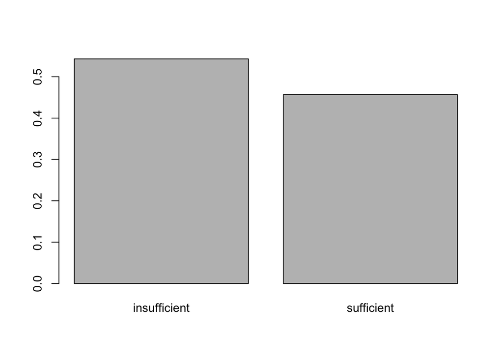

```r
train$coverage %>% table() %>% prop.table() %>% barplot()
```

#### Cek **proporsi** *coverage* per *src_area*

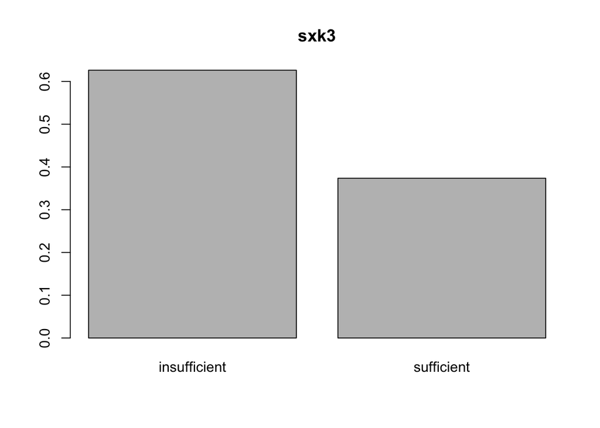

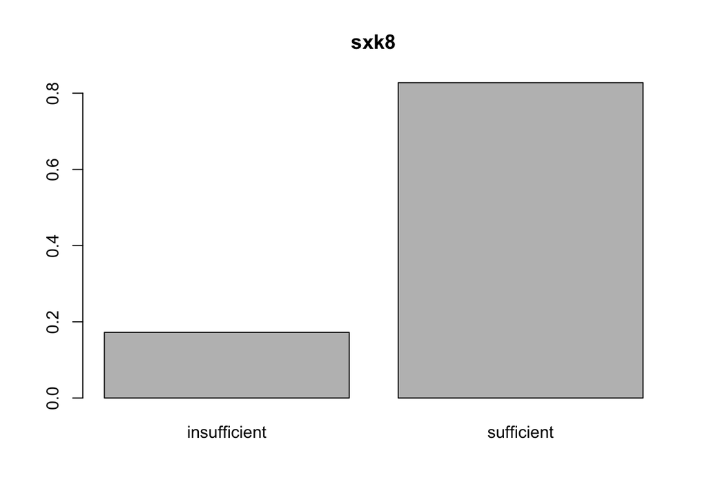

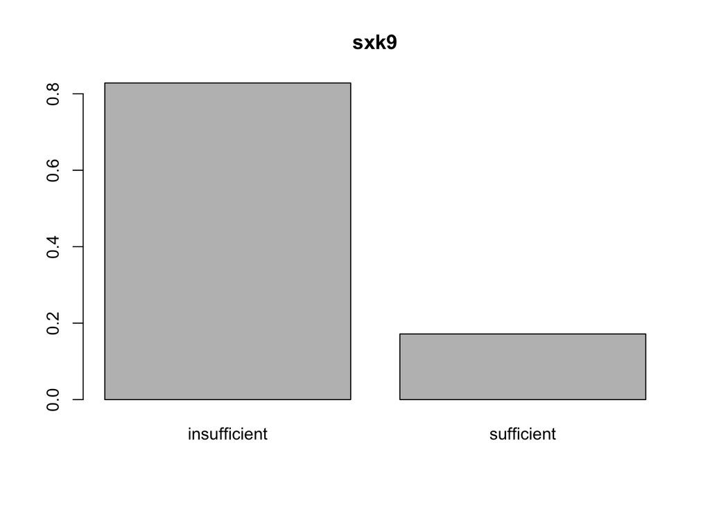

```r
for (area in unique(train$src_area)){
  filter(train, src_area == area)$coverage %>%
          table() %>%
          prop.table() %>%
          barplot(main = area)
}
```

Tidak balance pada “sxk8” dan “sxk9”

Apakah saya akan melakukan upsampling untuk setiap area? Tidak. Karena, sebelumnya saya sudah coba lakukan dan performa modelnya tidak sebagus tanpa upsampling. Berikut cara saya upsampling pada percobaan sebelumnya:

```r
# up_sxk3 <- upSample(
#   x = train %>% filter(src_area == "sxk3") %>% select(-coverage),
#   y = train[train$src_area == "sxk3", "coverage"]
# )
#
# up_sxk8 <- upSample(
#   x = train %>% filter(src_area == "sxk8") %>% select(-coverage),
#   y = train[train$src_area == "sxk8", "coverage"]
# )
#
# up_sxk9 <- upSample(
#   x = train %>% filter(src_area == "sxk9") %>% select(-coverage),
#   y = train[train$src_area == "sxk9", "coverage"]
# )
#
# # Gabungkan seluruh hasil upsample
# up_train <- bind_rows(up_sxk3, up_sxk8, up_sxk9)
```

#### Cek **kolerasi** antara ketiga *features* dengan *coverage*

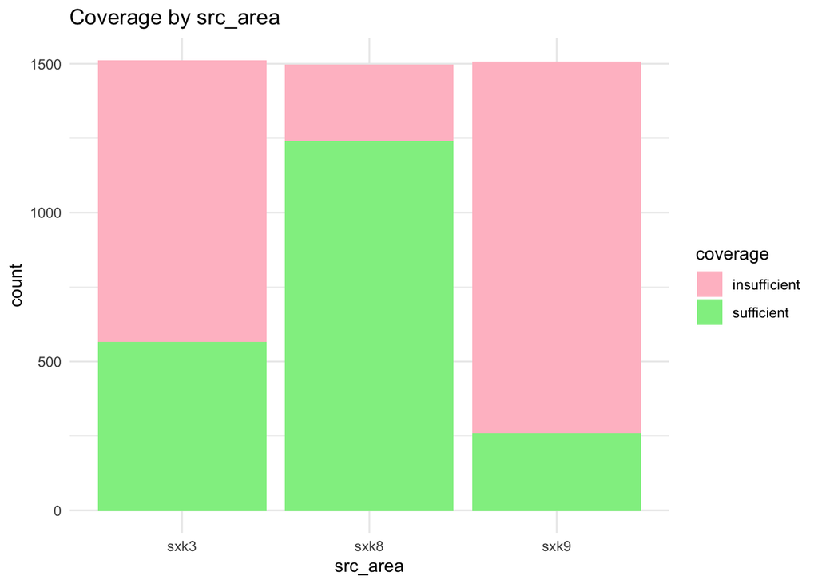

```r
ggplot(train, aes(x = src_area, fill = coverage)) +
  geom_bar(position = "stack") +
  scale_fill_manual(values = c("pink", "lightgreen")) +
  labs(title = "Coverage by src_area") +
  theme_minimal()
```

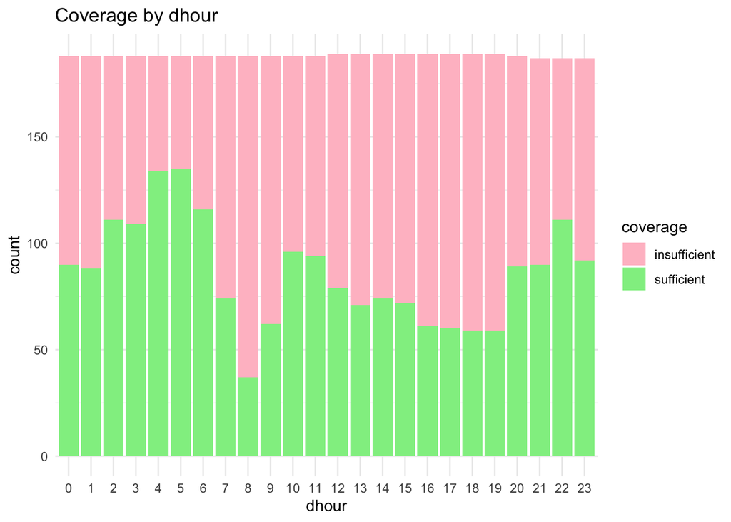

```r
ggplot(train, aes(x = dhour, fill = coverage)) +
  geom_bar(position = "stack") +
  scale_fill_manual(values = c("pink", "lightgreen")) +
  labs(title = "Coverage by dhour") +
  theme_minimal()
```

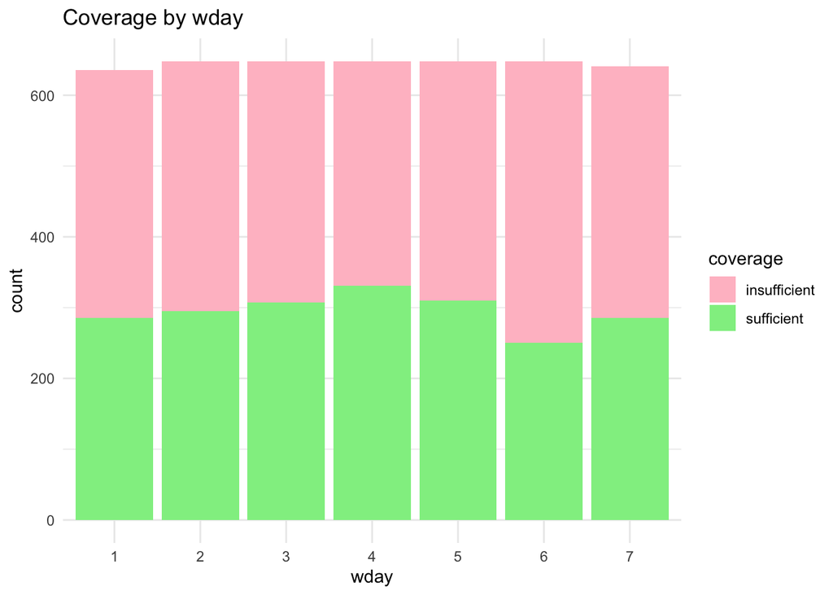

```r
ggplot(train, aes(x = wday, fill = coverage)) +
  geom_bar(position = "stack") +
  scale_fill_manual(values = c("pink", "lightgreen")) +
  labs(title = "Coverage by wday") +
  theme_minimal()
```

#### Cek **distribusi** *coverage* per *src_area* pada setiap *wday* dan *dhour*

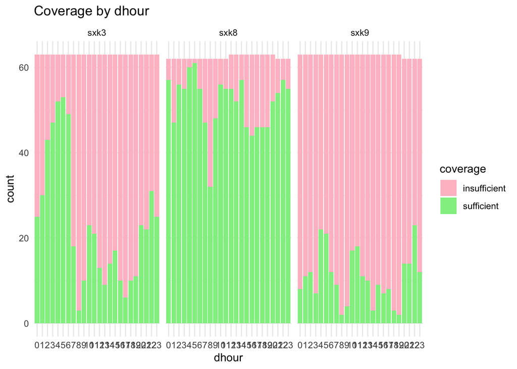

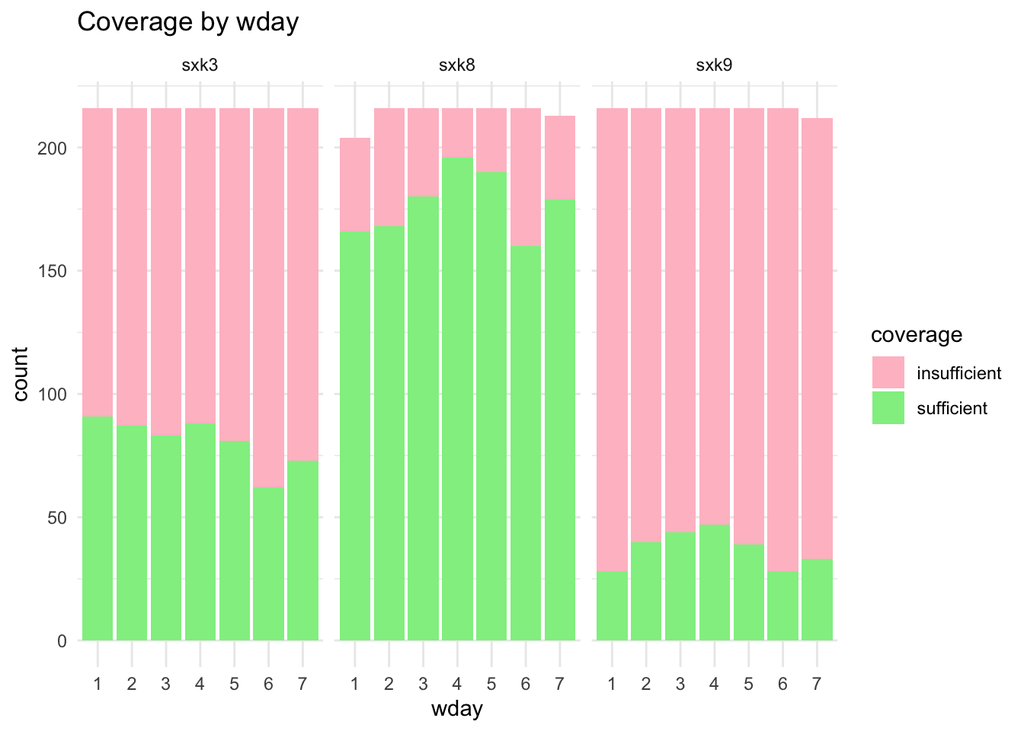

```r
for (feature in c("dhour", "wday")) {
  print(
    ggplot(train, aes(x = get(feature), fill = coverage)) +
      geom_bar(position = "stack") +
      scale_fill_manual(values = c("pink", "lightgreen")) +
      facet_wrap(~ src_area) +
      labs(title = paste("Coverage by", feature),
           x = feature) +
      theme_minimal()
  )
}
```

#### Cek **pesebaran data** untuk setiap *src_area*, *hour*, *wday*, dan *coverage*

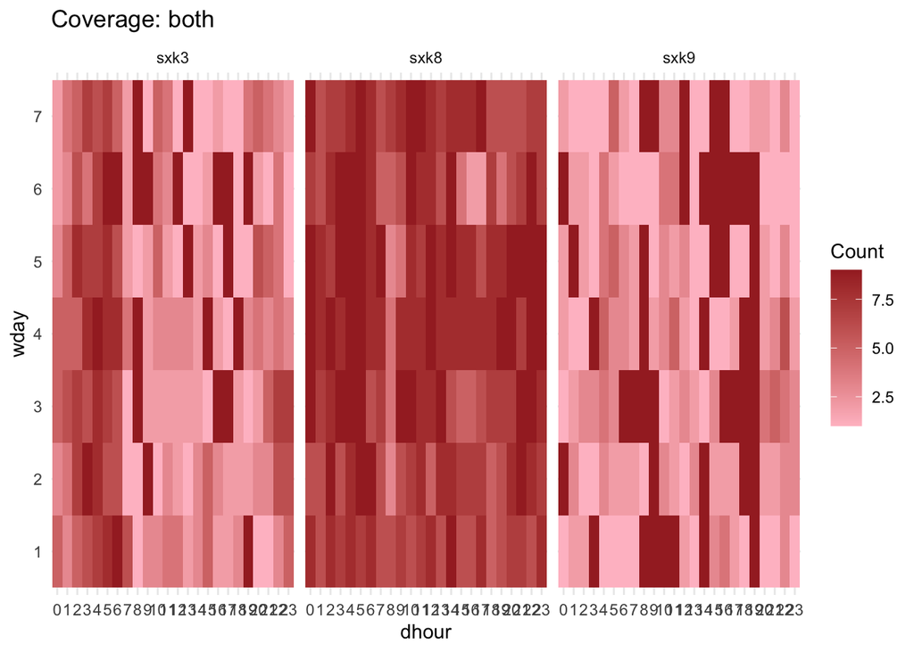

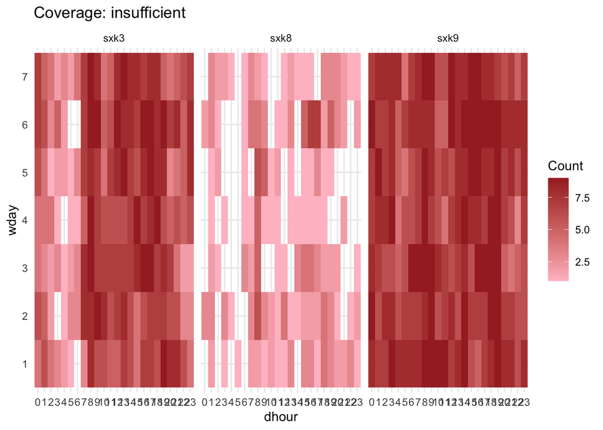

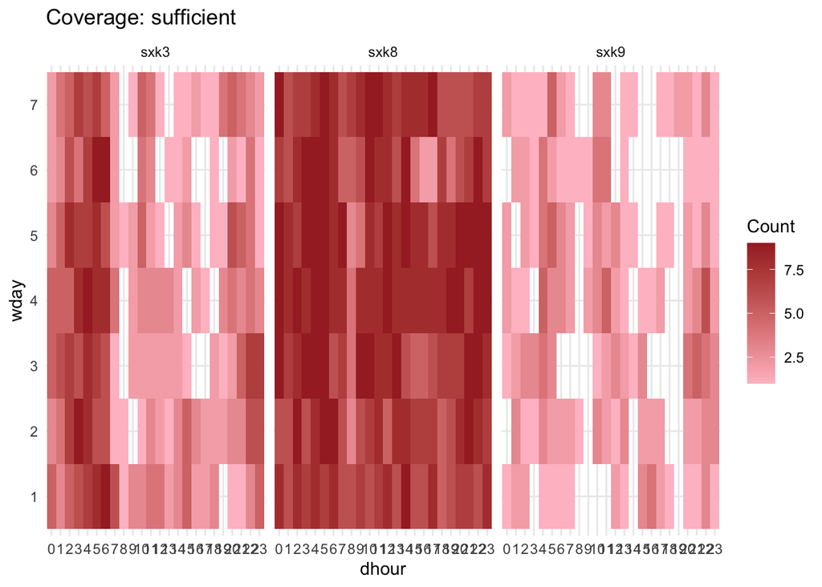

```r
for (cov in c("both", "insufficient", "sufficient")){
  heatmap_data <- train %>%
    group_by(src_area, dhour, wday, coverage) %>%
    summarise(count = n()) %>%
    ungroup()

  if (cov != "both"){
    heatmap_data <- heatmap_data %>%
      filter(coverage == cov)
  }

  print(
    ggplot(heatmap_data, aes(x = dhour, y = wday, fill = count)) +
      geom_tile() +
      facet_grid(. ~ src_area) +
      scale_fill_gradient(low = "pink", high = "brown") +  # You can choose different color palettes here
      labs(title = paste("Coverage:", cov),
           x = "dhour",
           y = "wday",
           fill = "Count") +
      theme_minimal()
  )
}
```

## CROSS VALIDATION

#### **Split data** untuk training dan testing

Karena baris data kita cukup sedikit, kita akan split data kita dengan proporsi 80/20

```r
# Set seed, biar acakannya tidak berubah-ubah
RNGkind(sample.kind = "Rounding")
set.seed(1)

# Ambil index untuk data train
indices <- sample(nrow(train), nrow(train) * 0.8)

# Subset data train dan test
train_data <- train[indices, ]
test_data <- train[-indices, ]

# Split features dan target
X_train <- train_data %>% select(-coverage)
y_train <- train_data$coverage
X_test <- test_data %>% select(-coverage)
y_test <- test_data$coverage
```

## MODEL FITTING

#### Metrics

**Akurasi** mengukur sejauh mana model klasifikasi benar dalam memprediksi semua jenis kasus, baik yang positif maupun negatif. **Sensitivity** mengukur kemampuan model untuk mengidentifikasi dengan benar kasus dari kelas positif (“insufficient”). Sensitivity yang tinggi berarti model efektif dalam menangkap sebagian besar kasus “insufficient yang akurat. Sensitivity yang rendah berarti model kurang mampu memprediksi kelas positif **Specificity** mengukur kemampuan model untuk mengidentifikasi dengan benar kasus dari kelas negatif. Spesicificity yang tinggi menunjukkan bahwa model bagus dalam mengenali kasus-kasus kelas negatif (”sufficient”), tetapi mungkin tidak sebaik itu dalam kasus positif.

Pada kasus ini, kita akan menggunakan score metrik pada prediksi data test sebagai pembanding agar score yang dibandingkan **bukanlah hasil overfittin**. Untuk kasus ini, karena saya rasa kedua kondisi (FN & FP) sama-sama penting, maka saya akan menggunakan **accuracy** sebagai metrik utama. Selanjutnya, saya akan melihat keseimbangan antara sensitivity dan specificity.

#### Algoritma **Naive Bayes**

Karena cocok dengan kasus kita dan **komputasi yang sangat cepat**, kita akan mencoba algoritma naive bayes sebagai percobaan pertama,

```r
# Train model naive bayes
model_nb <- naiveBayes(x = X_train, # Data features
                       y = y_train, # Data target
                       laplace = 1) # Set laplace = 1 untuk smoothing untuk mencegah terdapat probabilitas nol

# Prediksi data test menggunakan model naive bayes kita
pred_nb <- predict(model_nb, X_test)

# Evaluasi model naive bayes kita menggunakan confusion matrix
confusionMatrix(pred_nb, y_test)
```

```
## Confusion Matrix and Statistics
##
##               Reference
## Prediction     insufficient sufficient
##   insufficient          430        133
##   sufficient             63        278
##
##                Accuracy : 0.7832
##                  95% CI : (0.7549, 0.8096)
##     No Information Rate : 0.5454
##     P-Value [Acc > NIR] : < 2.2e-16
##
##                   Kappa : 0.5565
##
##  Mcnemar's Test P-Value : 8.283e-07
##
##             Sensitivity : 0.8722
##             Specificity : 0.6764
##          Pos Pred Value : 0.7638
##          Neg Pred Value : 0.8152
##              Prevalence : 0.5454
##          Detection Rate : 0.4757
##    Detection Prevalence : 0.6228
##       Balanced Accuracy : 0.7743
##
##        'Positive' Class : insufficient
##
```

Kita akan menggunakan score metrik pada prediksi data test sebagai pembanding agar score yang dibandingkan bukanlah hasil overfitting

#### Algoritma **Decision Tree Classifier**

Selain algoritma naive bayes, algoritma yang **cocok dengan kasus kita** adalah decision tree. Mari kita coba

```r
# Train model decision tree dengan mengatur control-nya agar modelnya lebih spesifik
model_dt <- ctree(coverage ~ .,
                  train_data,
                  control = ctree_control(mincriterion = 0.35,  # Set mincriterion = 0.35 agar node lebih mudah terbagi
                                          minsplit = 5,      # Set minsplit = 5 agar untuk syarat minimun split
                                          minbucket = 3))    # Set minbucket 3 sebagai syarat minimum pembuatan node baru

# Prediksi data test mengguanakan model decision tree kita
pred_dt <- predict(model_dt, X_test)

# Evaluasi model decision tee kita menggunakan confusion matrix
confusionMatrix(pred_dt, y_test)
```

```
## Confusion Matrix and Statistics
##
##               Reference
## Prediction     insufficient sufficient
##   insufficient          432        127
##   sufficient             61        284
##
##                Accuracy : 0.792
##                  95% CI : (0.7641, 0.8181)
##     No Information Rate : 0.5454
##     P-Value [Acc > NIR] : < 2.2e-16
##
##                   Kappa : 0.5749
##
##  Mcnemar's Test P-Value : 2.131e-06
##
##             Sensitivity : 0.8763
##             Specificity : 0.6910
##          Pos Pred Value : 0.7728
##          Neg Pred Value : 0.8232
##              Prevalence : 0.5454
##          Detection Rate : 0.4779
##    Detection Prevalence : 0.6184
##       Balanced Accuracy : 0.7836
##
##        'Positive' Class : insufficient
##
```

#### Algoritma **Random Forest**

Karena model decision tree kita memiliki performa yang cukup bagus, langkah baiknya adalah mencoba algoritma random forest

```r
RNGkind(sample.kind = "Rounding")
set.seed(1)

# Atur metode k-fold cross validation
ctrl <- trainControl(method = "repeatedcv",
                     number = 5, # Jumlah folds
                     repeats = 7) # Jumlah repetisi pelaksanaan cross-validation

# Awalnya, saya mengatur parameter number = 3 dan repeats = 5. Setelah saya atur number = 5 dan repeats = 7, performanya sedikit meningkat

# Train model random forest kita dengan control k-fold yang sudah kita atur
model_rf <- train(x = X_train, # Features
                  y = y_train, # Target
                  trControl = ctrl) # Control
# Prediksi data test menggunakan model random forest kita
pred_rf <- predict(model_rf, X_test)

# Evaluasi model random forest kita menggunakan confusion matrix
confusionMatrix(pred_rf, y_test)
```

```
## Confusion Matrix and Statistics
##
##               Reference
## Prediction     insufficient sufficient
##   insufficient          421        116
##   sufficient             72        295
##
##                Accuracy : 0.792
##                  95% CI : (0.7641, 0.8181)
##     No Information Rate : 0.5454
##     P-Value [Acc > NIR] : < 2.2e-16
##
##                   Kappa : 0.5769
##
##  Mcnemar's Test P-Value : 0.001712
##
##             Sensitivity : 0.8540
##             Specificity : 0.7178
##          Pos Pred Value : 0.7840
##          Neg Pred Value : 0.8038
##              Prevalence : 0.5454
##          Detection Rate : 0.4657
##    Detection Prevalence : 0.5940
##       Balanced Accuracy : 0.7859
##
##        'Positive' Class : insufficient
##
```

## TEST PREDICTING

#### **Baca data** test

```r
test_raw <- read.csv("data_input/data-test.csv")

test_raw %>% head()
```

```
##   src_area             datetime coverage
## 1     sxk3 2017-12-03T00:00:00Z       NA
## 2     sxk3 2017-12-03T01:00:00Z       NA
## 3     sxk3 2017-12-03T02:00:00Z       NA
## 4     sxk3 2017-12-03T03:00:00Z       NA
## 5     sxk3 2017-12-03T04:00:00Z       NA
## 6     sxk3 2017-12-03T05:00:00Z       NA
```

#### **Extract attributes** yang dibutuhkan untuk melakukan prediksi

```r
test <- test_raw %>%
  select(-coverage) %>%
  mutate(src_area = as.factor(src_area),
         datetime = ymd_hms(datetime),
         wday = as.factor(wday(datetime)),
         dhour = as.factor(hour(datetime)))

test %>% head(4)
```

```
##   src_area            datetime wday dhour
## 1     sxk3 2017-12-03 00:00:00    1     0
## 2     sxk3 2017-12-03 01:00:00    1     1
## 3     sxk3 2017-12-03 02:00:00    1     2
## 4     sxk3 2017-12-03 03:00:00    1     3
```

#### **Prediksi** data test dengan 3 model kita

```r
test$coverage_nb <- predict(model_nb, test)
test$coverage_dt <- predict(model_dt, test)
test$coverage_rf <- predict(model_rf, test)

test %>% head()
```

```
##   src_area            datetime wday dhour  coverage_nb  coverage_dt
## 1     sxk3 2017-12-03 00:00:00    1     0 insufficient insufficient
## 2     sxk3 2017-12-03 01:00:00    1     1 insufficient insufficient
## 3     sxk3 2017-12-03 02:00:00    1     2 insufficient   sufficient
## 4     sxk3 2017-12-03 03:00:00    1     3 insufficient   sufficient
## 5     sxk3 2017-12-03 04:00:00    1     4   sufficient   sufficient
## 6     sxk3 2017-12-03 05:00:00    1     5   sufficient   sufficient
##    coverage_rf
## 1 insufficient
## 2 insufficient
## 3   sufficient
## 4   sufficient
## 5   sufficient
## 6   sufficient
```

Kita akan coba melihat performa setiap model kita pada submisi algoritma.

#### Masukkan ke csv **submission** dan save untuk disubmit

```r
# Prediksi naive bayes
submission <- test_raw %>% mutate(coverage = test$coverage_nb)
write.csv(submission, "submission-ardian-nb.csv")

# Predikisi decision tree
submission <- test_raw %>% mutate(coverage = test$coverage_dt)
write.csv(submission, "submission-ardian-dt.csv")

# Prediksi random forest
submission <- test_raw %>% mutate(coverage = test$coverage_rf)
write.csv(submission, "submission-ardian-rf.csv")
```

Setelah dibandingkan di submisi, model decission tree menjadi model terbaik dengan score berikut: - Accuracy: 82% - Recall: 89% - Precision: 81% - Specificity: 74%

#### Train **seluruh data**

```r
model_dt_full <- ctree(coverage ~ .,
                  train,
                  control = ctree_control(mincriterion = 0.3,
                                          minsplit = 2,
                                          minbucket = 1))

pred_dt_full <- predict(model_dt_full, train)

confusionMatrix(pred_dt_full, train$coverage)
```

```
## Confusion Matrix and Statistics
##
##               Reference
## Prediction     insufficient sufficient
##   insufficient         2166        593
##   sufficient            288       1470
##
##                Accuracy : 0.805
##                  95% CI : (0.7931, 0.8164)
##     No Information Rate : 0.5433
##     P-Value [Acc > NIR] : < 2.2e-16
##
##                   Kappa : 0.6023
##
##  Mcnemar's Test P-Value : < 2.2e-16
##
##             Sensitivity : 0.8826
##             Specificity : 0.7126
##          Pos Pred Value : 0.7851
##          Neg Pred Value : 0.8362
##              Prevalence : 0.5433
##          Detection Rate : 0.4795
##    Detection Prevalence : 0.6108
##       Balanced Accuracy : 0.7976
##
##        'Positive' Class : insufficient
##
```

```r
# Prediksi random forest
submission <- test_raw %>% mutate(coverage = test$coverage_nb)
write.csv(submission, "submission-ardian-dt-full.csv")
```

Mari kita coba submit dan lihat performanya, tapi besok😁

## CONCLUSION

##### **Apakah tujuan saya tercapai?**

Ya, saya berhasil menghasilkan model dengan performa yang memuaskan. Model yang dibuat memiliki akurasi yang baik (82%), serta sensitivitas (recall) yang tinggi (89%), dan presisi yang layak (81%). Selain itu, spesifisitas model juga sebesar 74%, yang menunjukkan kemampuannya dalam mengidentifikasi dengan baik kasus-kasus negatif.

##### **Apakah masalah ini dapat diselesaikan dengan machine learning?**

Ya, masalah prediksi kecukupan driver pada lokasi tertentu dan waktu tertentu merupakan masalah yang dapat diselesaikan dengan baik menggunakan machine learning. Model decision tree yang Anda gunakan telah memberikan hasil yang bagus dalam mengklasifikasikan kasus-kasus “insufficient” dan “sufficient” pada lokasi dan waktu tertentu.

##### **Model apa yang Anda gunakan dan bagaimana performanya?**

Model yang digunakan adalah Decision Tree Classifier. Model ini berhasil mencapai akurasi 82%, yang berarti sekitar 82% prediksi yang dilakukan oleh model sesuai dengan kenyataan. Performa yang lebih penting lagi terlihat dalam recall (89%), yang mengindikasikan kemampuan model dalam menangkap sebagian besar kasus “insufficient” yang sebenarnya. Presisi yang mencapai 81% juga menunjukkan bahwa ketika model memprediksi “insufficient,” prediksinya cenderung benar. Spesifisitas sebesar 74% menunjukkan kemampuan model dalam mengidentifikasi “sufficient” dengan baik.

##### **Apa potensi implementasi bisnis dari proyek Capstone Anda?**

Potensi implementasi bisnis dari proyek Capstone ini sangat menjanjikan. Dengan model ini, Anda dapat membantu mengoptimalkan alokasi driver pada lokasi dan waktu tertentu. Misalnya, dengan memprediksi kecukupan driver, perusahaan dapat mengambil langkah-langkah yang lebih baik dalam mengatur penjadwalan driver, menghindari kekurangan driver, dan meningkatkan efisiensi layanan. Hal ini dapat mengurangi ketidaknyamanan pelanggan akibat keterlambatan atau ketidaktersediaan driver. Selain itu, analisis lebih lanjut dari output model ini juga dapat memberikan wawasan berharga untuk pengambilan keputusan dalam mengoptimalkan sumber daya dan meningkatkan pengalaman pelanggan.